# R Notebook

### Logan wants to open a baby store chain with the hope of expanding his business overseas. He is interested in finding out whether the average sales are associated with the characteristics of the store location. To understand this relationship, he gathered data on car seat sales for 500 locations. Attributed include:

### Sales - Sales (in thousands of dollars at each location)

### Prices - Price company charges for car seats at each site

### CompPrice - Price charged by competitor at each location

### Income - Median income in the community (in 1000’s of dollars)

### Education - Education level at the location

### Age - Average age of the local population

### Advertising - Local advertising budget for company at each location (in thousands of dollars)

### Accidents - Average monthly accidents in the area

### Urban - A factor with levels: 0 and 1 to indicate whether the store is in an urban or rural location (1 if urban, 0 if rural)

### US - A factor with levels 0 and 1 to indicate whether the store is in the US or not (1 if in US, 0 if other)

### ShelveLoc - A factor with levels Bad, Good and Medium indicating the quality of the shelving location for the car seats at each site

### Logan is seeking your assisstance to build a model to make inferences and predictions about the car seat sales. To achieve this goal, you are expected to do below:

### (1). First, you are going to split the dataset into two: training and testing set. Use 400 observations in the dataset to train your models and remaining 100 to validate the prediction performance. When subsampling 400 observations for the training data, I want you to use a random seed. This random seed MUST have the format “300GroupNo”. For instance, if your group is 1, then your random seed should be 30001. If your group number is 11, then your random seed should be 30011, etc. Remember, for descriptive analysis as well as for developing the model, you are going to use your training set only. You will use the testing set to validate the prediction performance of the developed model

### You may adapt a code like below to split the data into testing and training set

```r
#Load the necessary packages
if (!require(readxl)) install.packages("readxl")
if (!require(MASS)) install.packages("MASS")
if (!require(leaps)) install.packages("leaps")
if (!require(corrplot)) install.packages("corrplot")

#Loading packages
library(readxl)
library(MASS)
library(leaps)
library(corrplot)
library(knitr)
library(kableExtra)
library(ggplot2)
library(leaps)

#retrieve data
Cseat = read.csv("carseat.csv")

#Setting the random seed
group_number = 1
set.seed(30000+group_number)

#Decide which records to keep in the training set
trainRec = sort(sample(1:nrow(Cseat), size = 400))

#Extract indexes that are not in the trainRec as test records
testRec = setdiff(1:nrow(Cseat), trainRec)

#Extract the index rows in the trainRec and keep them in the training set
trainSeat = Cseat[trainRec, ]

#Extract indexed rows from testRec and keep them in the test set
testSeat = Cseat[testRec, ]
```

### (2) You should pick a model using variable selection approaches such as stepwise, best subset with different information criteria such as AIC, BIC, etc. To pick the model, you are going to use your training set. You must clearly justify the reason for your suggested model, which include model assumptions as well.

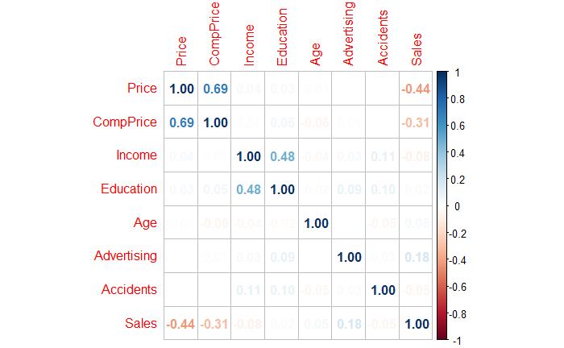

```r
#Conversion of categorical variable data
trainSeat$Urban = as.factor(trainSeat$Urban)
trainSeat$US = as.factor(trainSeat$US)
trainSeat$ShelveLoc = as.factor(trainSeat$ShelveLoc)

#Plotting the correlation matrix between variables
CseatCorMat = cor(trainSeat[, sapply(trainSeat, is.numeric)])
corrplot(CseatCorMat, method = "number")
```

```r
#MLR-null Model
nullModel = lm(Sales ~ 1, data = trainSeat) #The model has only intercept
#full-model
fullModel = lm(Sales ~ Price + CompPrice + Income + Education + Age + Advertising + Accidents + Urban + US + ShelveLoc, data = trainSeat)
```

```r
##AIC
#forward(AIC)
stepForwardAIC = step(nullModel, scope = list(lower = nullModel, upper = fullModel), direction = "forward", k = 2)
```

```
Start:  AIC=1143.49
Sales ~ 1

              Df Sum of Sq    RSS     AIC
+ ShelveLoc    2    4900.2 2040.7  657.84
+ Price        1    1329.5 5611.5 1060.44
+ CompPrice    1     675.3 6265.6 1104.55
+ Advertising  1     236.9 6704.0 1131.60
+ Income       1      43.7 6897.2 1142.96
<none>                     6940.9 1143.49
+ Accidents    1      18.0 6923.0 1144.45
+ Age          1      16.6 6924.3 1144.53
+ US           1       9.7 6931.3 1144.93
+ Education    1       3.0 6938.0 1145.32
+ Urban        1       0.1 6940.8 1145.49

Step:  AIC=657.84
Sales ~ ShelveLoc

              Df Sum of Sq     RSS    AIC
+ Price        1   1200.73  840.02 304.79
+ CompPrice    1    570.07 1470.68 528.81
+ Advertising  1    138.61 1902.14 631.71
+ Education    1     15.26 2025.49 656.84
<none>                     2040.75 657.84
+ Income       1      6.01 2034.74 658.66
+ Age          1      3.59 2037.16 659.14
+ Urban        1      0.13 2040.62 659.82
+ Accidents    1      0.08 2040.67 659.83
+ US           1      0.01 2040.74 659.84

Step:  AIC=304.79
Sales ~ ShelveLoc + Price

              Df Sum of Sq    RSS    AIC
+ Advertising  1   136.451 703.57 235.88
+ Education    1    25.717 814.30 294.35
+ Income       1    13.412 826.61 300.35
<none>                     840.02 304.79
+ Age          1     2.154 837.87 305.76
```

[output cut: 14 more lines]

```
+ US         1    0.2771 703.29 237.72
+ Urban      1    0.0790 703.49 237.84
+ CompPrice  1    0.0197 703.55 237.87

Step:  AIC=228.64
Sales ~ ShelveLoc + Price + Advertising + Education

            Df Sum of Sq    RSS    AIC
<none>                   687.51 228.64
+ Age        1   2.84160 684.67 228.99
+ Income     1   2.00945 685.50 229.47
+ Accidents  1   0.82874 686.68 230.16
+ US         1   0.22948 687.28 230.51
+ Urban      1   0.19090 687.32 230.53
+ CompPrice  1   0.08949 687.42 230.59
```

```r
summary(stepForwardAIC)
```

```
Call:
lm(formula = Sales ~ ShelveLoc + Price + Advertising + Education,
    data = trainSeat)

Residuals:
    Min      1Q  Median      3Q     Max
-3.7195 -0.8423 -0.0432  0.8679  3.8688

Coefficients:
                 Estimate Std. Error t value Pr(>|t|)
(Intercept)     21.585761   0.547458  39.429  < 2e-16 ***
ShelveLocGood    9.009206   0.185392  48.595  < 2e-16 ***
ShelveLocMedium  2.937823   0.172139  17.067  < 2e-16 ***
Price           -0.078556   0.002987 -26.296  < 2e-16 ***
Advertising      0.090855   0.010658   8.524 3.32e-16 ***
Education        0.086501   0.028511   3.034  0.00257 **
---
Signif. codes:  0 ‘***’ 0.001 ‘**’ 0.01 ‘*’ 0.05 ‘.’ 0.1 ‘ ’ 1

Residual standard error: 1.321 on 394 degrees of freedom
Multiple R-squared:  0.9009,    Adjusted R-squared:  0.8997
F-statistic: 716.7 on 5 and 394 DF,  p-value: < 2.2e-16
```

```r
aic_value1=AIC(stepForwardAIC)
```

```r
#BACK(AIC)
stepBackwardAIC = step(fullModel, scope = list(lower = nullModel, upper = fullModel), direction = "backward", k = 2)
```

```
Start:  AIC=236.9
Sales ~ Price + CompPrice + Income + Education + Age + Advertising +
    Accidents + Urban + US + ShelveLoc

              Df Sum of Sq    RSS     AIC
- CompPrice    1       0.0  681.1  234.91
- Urban        1       0.2  681.3  235.01
- US           1       0.3  681.5  235.11
- Accidents    1       0.8  681.9  235.36
- Income       1       2.5  683.6  236.36
- Age          1       2.8  683.9  236.54
<none>                      681.1  236.90
- Education    1       8.1  689.2  239.65
- Advertising  1     126.7  807.9  303.17
- Price        1     624.8 1305.9  495.28
- ShelveLoc    2    4594.4 5275.5 1051.74

Step:  AIC=234.91
Sales ~ Price + Income + Education + Age + Advertising + Accidents +
    Urban + US + ShelveLoc

              Df Sum of Sq    RSS     AIC
- Urban        1       0.2  681.3  233.02
- US           1       0.3  681.5  233.11
- Accidents    1       0.8  681.9  233.37
- Income       1       2.5  683.6  234.38
- Age          1       2.8  684.0  234.57
<none>                      681.1  234.91
- Education    1       8.1  689.2  237.65
- Advertising  1     126.7  807.9  301.17
- Price        1    1207.2 1888.3  640.79
- ShelveLoc    2    4596.7 5277.8 1049.92

Step:  AIC=233.02
Sales ~ Price + Income + Education + Age + Advertising + Accidents +
    US + ShelveLoc

              Df Sum of Sq    RSS     AIC
- US           1       0.3  681.7  231.22
- Accidents    1       0.8  682.1  231.50
```

[output cut: 39 more lines]

```
<none>                      684.7  228.99
- Education    1      16.4  701.0  236.44
- Advertising  1     127.1  811.8  295.10
- Price        1    1205.1 1889.8  633.10
- ShelveLoc    2    4675.9 5360.6 1048.14

Step:  AIC=228.64
Sales ~ Price + Education + Advertising + ShelveLoc

              Df Sum of Sq    RSS     AIC
<none>                      687.5  228.64
- Education    1      16.1  703.6  235.88
- Advertising  1     126.8  814.3  294.35
- Price        1    1206.6 1894.1  632.02
- ShelveLoc    2    4687.3 5374.8 1047.21
```

```r
summary(stepBackwardAIC)
```

```
Call:
lm(formula = Sales ~ Price + Education + Advertising + ShelveLoc,
    data = trainSeat)

Residuals:
    Min      1Q  Median      3Q     Max
-3.7195 -0.8423 -0.0432  0.8679  3.8688

Coefficients:
                 Estimate Std. Error t value Pr(>|t|)
(Intercept)     21.585761   0.547458  39.429  < 2e-16 ***
Price           -0.078556   0.002987 -26.296  < 2e-16 ***
Education        0.086501   0.028511   3.034  0.00257 **
Advertising      0.090855   0.010658   8.524 3.32e-16 ***
ShelveLocGood    9.009206   0.185392  48.595  < 2e-16 ***
ShelveLocMedium  2.937823   0.172139  17.067  < 2e-16 ***
---
Signif. codes:  0 ‘***’ 0.001 ‘**’ 0.01 ‘*’ 0.05 ‘.’ 0.1 ‘ ’ 1

Residual standard error: 1.321 on 394 degrees of freedom
Multiple R-squared:  0.9009,    Adjusted R-squared:  0.8997
F-statistic: 716.7 on 5 and 394 DF,  p-value: < 2.2e-16
```

```r
aic_value2=AIC(stepBackwardAIC)
```

```r
#bI(AIC)
stepBothAIC = step(nullModel, scope = list(lower = nullModel, upper = fullModel), direction = "both", k = 2)
```

```
Start:  AIC=1143.49
Sales ~ 1

              Df Sum of Sq    RSS     AIC
+ ShelveLoc    2    4900.2 2040.7  657.84
+ Price        1    1329.5 5611.5 1060.44
+ CompPrice    1     675.3 6265.6 1104.55
+ Advertising  1     236.9 6704.0 1131.60
+ Income       1      43.7 6897.2 1142.96
<none>                     6940.9 1143.49
+ Accidents    1      18.0 6923.0 1144.45
+ Age          1      16.6 6924.3 1144.53
+ US           1       9.7 6931.3 1144.93
+ Education    1       3.0 6938.0 1145.32
+ Urban        1       0.1 6940.8 1145.49

Step:  AIC=657.84
Sales ~ ShelveLoc

              Df Sum of Sq    RSS     AIC
+ Price        1    1200.7  840.0  304.79
+ CompPrice    1     570.1 1470.7  528.81
+ Advertising  1     138.6 1902.1  631.71
+ Education    1      15.3 2025.5  656.84
<none>                     2040.7  657.84
+ Income       1       6.0 2034.7  658.66
+ Age          1       3.6 2037.2  659.14
+ Urban        1       0.1 2040.6  659.82
+ Accidents    1       0.1 2040.7  659.83
+ US           1       0.0 2040.7  659.84
- ShelveLoc    2    4900.2 6940.9 1143.49

Step:  AIC=304.79
Sales ~ ShelveLoc + Price

              Df Sum of Sq    RSS     AIC
+ Advertising  1     136.5  703.6  235.88
+ Education    1      25.7  814.3  294.35
+ Income       1      13.4  826.6  300.35
<none>                      840.0  304.79
```

[output cut: 24 more lines]

```
Step:  AIC=228.64
Sales ~ ShelveLoc + Price + Advertising + Education

              Df Sum of Sq    RSS     AIC
<none>                      687.5  228.64
+ Age          1       2.8  684.7  228.99
+ Income       1       2.0  685.5  229.47
+ Accidents    1       0.8  686.7  230.16
+ US           1       0.2  687.3  230.51
+ Urban        1       0.2  687.3  230.53
+ CompPrice    1       0.1  687.4  230.59
- Education    1      16.1  703.6  235.88
- Advertising  1     126.8  814.3  294.35
- Price        1    1206.6 1894.1  632.02
- ShelveLoc    2    4687.3 5374.8 1047.21
```

```r
summary(stepBothAIC)
```

```
Call:
lm(formula = Sales ~ ShelveLoc + Price + Advertising + Education,
    data = trainSeat)

Residuals:
    Min      1Q  Median      3Q     Max
-3.7195 -0.8423 -0.0432  0.8679  3.8688

Coefficients:
                 Estimate Std. Error t value Pr(>|t|)
(Intercept)     21.585761   0.547458  39.429  < 2e-16 ***
ShelveLocGood    9.009206   0.185392  48.595  < 2e-16 ***
ShelveLocMedium  2.937823   0.172139  17.067  < 2e-16 ***
Price           -0.078556   0.002987 -26.296  < 2e-16 ***
Advertising      0.090855   0.010658   8.524 3.32e-16 ***
Education        0.086501   0.028511   3.034  0.00257 **
---
Signif. codes:  0 ‘***’ 0.001 ‘**’ 0.01 ‘*’ 0.05 ‘.’ 0.1 ‘ ’ 1

Residual standard error: 1.321 on 394 degrees of freedom
Multiple R-squared:  0.9009,    Adjusted R-squared:  0.8997
F-statistic: 716.7 on 5 and 394 DF,  p-value: < 2.2e-16
```

```r
aic_value3 = AIC(stepBothAIC)
```

```r
##BIC
#forward(BIC)
stepForwardBIC = step(nullModel, scope = list(lower = nullModel, upper = fullModel), direction = "forward", k = log(nrow(trainSeat)))
```

```
Start:  AIC=1147.48
Sales ~ 1

              Df Sum of Sq    RSS     AIC
+ ShelveLoc    2    4900.2 2040.7  669.82
+ Price        1    1329.5 5611.5 1068.42
+ CompPrice    1     675.3 6265.6 1112.53
+ Advertising  1     236.9 6704.0 1139.58
<none>                     6940.9 1147.48
+ Income       1      43.7 6897.2 1150.95
+ Accidents    1      18.0 6923.0 1152.44
+ Age          1      16.6 6924.3 1152.51
+ US           1       9.7 6931.3 1152.92
+ Education    1       3.0 6938.0 1153.30
+ Urban        1       0.1 6940.8 1153.47

Step:  AIC=669.82
Sales ~ ShelveLoc

              Df Sum of Sq     RSS    AIC
+ Price        1   1200.73  840.02 320.75
+ CompPrice    1    570.07 1470.68 544.77
+ Advertising  1    138.61 1902.14 647.67
<none>                     2040.75 669.82
+ Education    1     15.26 2025.49 672.81
+ Income       1      6.01 2034.74 674.63
+ Age          1      3.59 2037.16 675.10
+ Urban        1      0.13 2040.62 675.78
+ Accidents    1      0.08 2040.67 675.79
+ US           1      0.01 2040.74 675.81

Step:  AIC=320.75
Sales ~ ShelveLoc + Price

              Df Sum of Sq    RSS    AIC
+ Advertising  1   136.451 703.57 255.84
+ Education    1    25.717 814.30 314.31
+ Income       1    13.412 826.61 320.30
<none>                     840.02 320.75
+ Age          1     2.154 837.87 325.72
```

[output cut: 14 more lines]

```
+ US         1    0.2771 703.29 261.67
+ Urban      1    0.0790 703.49 261.79
+ CompPrice  1    0.0197 703.55 261.82

Step:  AIC=252.59
Sales ~ ShelveLoc + Price + Advertising + Education

            Df Sum of Sq    RSS    AIC
<none>                   687.51 252.59
+ Age        1   2.84160 684.67 256.93
+ Income     1   2.00945 685.50 257.41
+ Accidents  1   0.82874 686.68 258.10
+ US         1   0.22948 687.28 258.45
+ Urban      1   0.19090 687.32 258.47
+ CompPrice  1   0.08949 687.42 258.53
```

```r
summary(stepForwardBIC)
```

```
Call:
lm(formula = Sales ~ ShelveLoc + Price + Advertising + Education,
    data = trainSeat)

Residuals:
    Min      1Q  Median      3Q     Max
-3.7195 -0.8423 -0.0432  0.8679  3.8688

Coefficients:
                 Estimate Std. Error t value Pr(>|t|)
(Intercept)     21.585761   0.547458  39.429  < 2e-16 ***
ShelveLocGood    9.009206   0.185392  48.595  < 2e-16 ***
ShelveLocMedium  2.937823   0.172139  17.067  < 2e-16 ***
Price           -0.078556   0.002987 -26.296  < 2e-16 ***
Advertising      0.090855   0.010658   8.524 3.32e-16 ***
Education        0.086501   0.028511   3.034  0.00257 **
---
Signif. codes:  0 ‘***’ 0.001 ‘**’ 0.01 ‘*’ 0.05 ‘.’ 0.1 ‘ ’ 1

Residual standard error: 1.321 on 394 degrees of freedom
Multiple R-squared:  0.9009,    Adjusted R-squared:  0.8997
F-statistic: 716.7 on 5 and 394 DF,  p-value: < 2.2e-16
```

```r
bic_value1=BIC(stepForwardBIC)
```

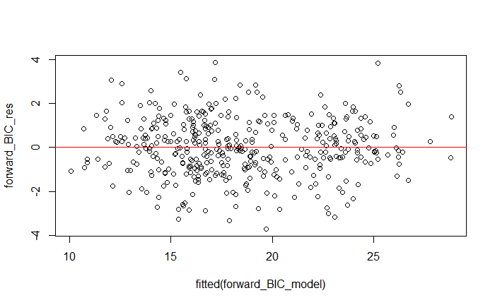

```r
forward_BIC_model <- lm(formula = Sales ~ ShelveLoc + Price + Advertising + Education, data = trainSeat)
forward_BIC_res <- resid(forward_BIC_model)
plot(fitted(forward_BIC_model), forward_BIC_res)
abline(h = 0, col = 'red')
```

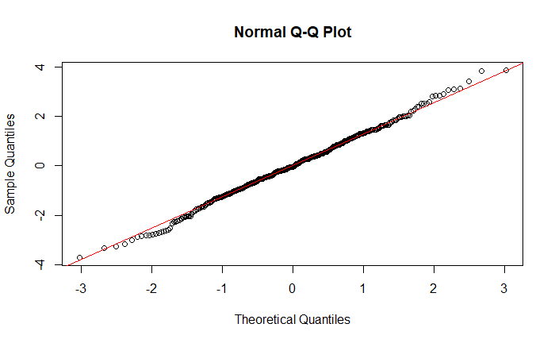

```r
qqnorm(forward_BIC_res)
qqline(forward_BIC_res, col = 'red')
```

### Normality: Based on the QQ plot, the points lie along the reference line so we can assume normality

### Equal Variance: The residuals are randomly scattered within a constant band so we can assume equal variance

```r
#back(BIC)
stepBackwardBIC = step(fullModel, scope = list(lower = nullModel, upper = fullModel), direction = "backward", k = log(nrow(trainSeat)))
```

```
Start:  AIC=284.8
Sales ~ Price + CompPrice + Income + Education + Age + Advertising +
    Accidents + Urban + US + ShelveLoc

              Df Sum of Sq    RSS     AIC
- CompPrice    1       0.0  681.1  278.82
- Urban        1       0.2  681.3  278.92
- US           1       0.3  681.5  279.01
- Accidents    1       0.8  681.9  279.27
- Income       1       2.5  683.6  280.26
- Age          1       2.8  683.9  280.44
- Education    1       8.1  689.2  283.55
<none>                      681.1  284.80
- Advertising  1     126.7  807.9  347.07
- Price        1     624.8 1305.9  539.19
- ShelveLoc    2    4594.4 5275.5 1091.66

Step:  AIC=278.82
Sales ~ Price + Income + Education + Age + Advertising + Accidents +
    Urban + US + ShelveLoc

              Df Sum of Sq    RSS     AIC
- Urban        1       0.2  681.3  272.94
- US           1       0.3  681.5  273.03
- Accidents    1       0.8  681.9  273.29
- Income       1       2.5  683.6  274.30
- Age          1       2.8  684.0  274.49
- Education    1       8.1  689.2  277.56
<none>                      681.1  278.82
- Advertising  1     126.7  807.9  341.08
- Price        1    1207.2 1888.3  680.71
- ShelveLoc    2    4596.7 5277.8 1085.85

Step:  AIC=272.94
Sales ~ Price + Income + Education + Age + Advertising + Accidents +
    US + ShelveLoc

              Df Sum of Sq    RSS     AIC
- US           1       0.3  681.7  267.15
- Accidents    1       0.8  682.1  267.43
```

[output cut: 39 more lines]

```
<none>                      684.7  256.93
- Education    1      16.4  701.0  260.39
- Advertising  1     127.1  811.8  319.05
- Price        1    1205.1 1889.8  657.05
- ShelveLoc    2    4675.9 5360.6 1068.10

Step:  AIC=252.59
Sales ~ Price + Education + Advertising + ShelveLoc

              Df Sum of Sq    RSS     AIC
<none>                      687.5  252.59
- Education    1      16.1  703.6  255.84
- Advertising  1     126.8  814.3  314.31
- Price        1    1206.6 1894.1  651.98
- ShelveLoc    2    4687.3 5374.8 1063.17
```

```r
summary(stepBackwardBIC)
```

```
Call:
lm(formula = Sales ~ Price + Education + Advertising + ShelveLoc,
    data = trainSeat)

Residuals:
    Min      1Q  Median      3Q     Max
-3.7195 -0.8423 -0.0432  0.8679  3.8688

Coefficients:
                 Estimate Std. Error t value Pr(>|t|)
(Intercept)     21.585761   0.547458  39.429  < 2e-16 ***
Price           -0.078556   0.002987 -26.296  < 2e-16 ***
Education        0.086501   0.028511   3.034  0.00257 **
Advertising      0.090855   0.010658   8.524 3.32e-16 ***
ShelveLocGood    9.009206   0.185392  48.595  < 2e-16 ***
ShelveLocMedium  2.937823   0.172139  17.067  < 2e-16 ***
---
Signif. codes:  0 ‘***’ 0.001 ‘**’ 0.01 ‘*’ 0.05 ‘.’ 0.1 ‘ ’ 1

Residual standard error: 1.321 on 394 degrees of freedom
Multiple R-squared:  0.9009,    Adjusted R-squared:  0.8997
F-statistic: 716.7 on 5 and 394 DF,  p-value: < 2.2e-16
```

```r
bic_value2=BIC(stepBackwardBIC)
```

```r
#BI(BIC)
stepBothBIC = step(nullModel, scope = list(lower = nullModel, upper = fullModel), direction = "both", k = log(nrow(trainSeat)))
```

```
Start:  AIC=1147.48
Sales ~ 1

              Df Sum of Sq    RSS     AIC
+ ShelveLoc    2    4900.2 2040.7  669.82
+ Price        1    1329.5 5611.5 1068.42
+ CompPrice    1     675.3 6265.6 1112.53
+ Advertising  1     236.9 6704.0 1139.58
<none>                     6940.9 1147.48
+ Income       1      43.7 6897.2 1150.95
+ Accidents    1      18.0 6923.0 1152.44
+ Age          1      16.6 6924.3 1152.51
+ US           1       9.7 6931.3 1152.92
+ Education    1       3.0 6938.0 1153.30
+ Urban        1       0.1 6940.8 1153.47

Step:  AIC=669.82
Sales ~ ShelveLoc

              Df Sum of Sq    RSS     AIC
+ Price        1    1200.7  840.0  320.75
+ CompPrice    1     570.1 1470.7  544.77
+ Advertising  1     138.6 1902.1  647.67
<none>                     2040.7  669.82
+ Education    1      15.3 2025.5  672.81
+ Income       1       6.0 2034.7  674.63
+ Age          1       3.6 2037.2  675.10
+ Urban        1       0.1 2040.6  675.78
+ Accidents    1       0.1 2040.7  675.79
+ US           1       0.0 2040.7  675.81
- ShelveLoc    2    4900.2 6940.9 1147.48

Step:  AIC=320.75
Sales ~ ShelveLoc + Price

              Df Sum of Sq    RSS     AIC
+ Advertising  1     136.5  703.6  255.84
+ Education    1      25.7  814.3  314.31
+ Income       1      13.4  826.6  320.30
<none>                      840.0  320.75
```

[output cut: 24 more lines]

```
Step:  AIC=252.59
Sales ~ ShelveLoc + Price + Advertising + Education

              Df Sum of Sq    RSS     AIC
<none>                      687.5  252.59
- Education    1      16.1  703.6  255.84
+ Age          1       2.8  684.7  256.93
+ Income       1       2.0  685.5  257.41
+ Accidents    1       0.8  686.7  258.10
+ US           1       0.2  687.3  258.45
+ Urban        1       0.2  687.3  258.47
+ CompPrice    1       0.1  687.4  258.53
- Advertising  1     126.8  814.3  314.31
- Price        1    1206.6 1894.1  651.98
- ShelveLoc    2    4687.3 5374.8 1063.17
```

```r
summary(stepBothBIC)
```

```
Call:
lm(formula = Sales ~ ShelveLoc + Price + Advertising + Education,
    data = trainSeat)

Residuals:
    Min      1Q  Median      3Q     Max
-3.7195 -0.8423 -0.0432  0.8679  3.8688

Coefficients:
                 Estimate Std. Error t value Pr(>|t|)
(Intercept)     21.585761   0.547458  39.429  < 2e-16 ***
ShelveLocGood    9.009206   0.185392  48.595  < 2e-16 ***
ShelveLocMedium  2.937823   0.172139  17.067  < 2e-16 ***
Price           -0.078556   0.002987 -26.296  < 2e-16 ***
Advertising      0.090855   0.010658   8.524 3.32e-16 ***
Education        0.086501   0.028511   3.034  0.00257 **
---
Signif. codes:  0 ‘***’ 0.001 ‘**’ 0.01 ‘*’ 0.05 ‘.’ 0.1 ‘ ’ 1

Residual standard error: 1.321 on 394 degrees of freedom
Multiple R-squared:  0.9009,    Adjusted R-squared:  0.8997
F-statistic: 716.7 on 5 and 394 DF,  p-value: < 2.2e-16
```

```r
bic_value3=BIC(stepBothBIC)
```

```r
# Best subset method
best_subset <- regsubsets(Sales ~ ., data = trainSeat, nbest = 1)
summary(best_subset_model)
```

```
Subset selection object
Call: regsubsets.formula(Sales ~ ., data = trainSeat, nbest = 1)
11 Variables  (and intercept)
                Forced in Forced out
Price               FALSE      FALSE
CompPrice           FALSE      FALSE
Income              FALSE      FALSE
Education           FALSE      FALSE
Age                 FALSE      FALSE
Advertising         FALSE      FALSE
Accidents           FALSE      FALSE
Urban               FALSE      FALSE
US                  FALSE      FALSE
ShelveLocGood       FALSE      FALSE
ShelveLocMedium     FALSE      FALSE
1 subsets of each size up to 8
Selection Algorithm: exhaustive
         Price CompPrice Income Education Age Advertising Accidents Urban US  ShelveLocGood ShelveLocMedium
1  ( 1 ) " "   " "       " "    " "       " " " "         " "       " "   " " "*"           " "
2  ( 1 ) "*"   " "       " "    " "       " " " "         " "       " "   " " "*"           " "
3  ( 1 ) "*"   " "       " "    " "       " " " "         " "       " "   " " "*"           "*"
4  ( 1 ) "*"   " "       " "    " "       " " "*"         " "       " "   " " "*"           "*"
5  ( 1 ) "*"   " "       " "    "*"       " " "*"         " "       " "   " " "*"           "*"
6  ( 1 ) "*"   " "       " "    "*"       "*" "*"         " "       " "   " " "*"           "*"
7  ( 1 ) "*"   " "       "*"    "*"       "*" "*"         " "       " "   " " "*"           "*"
8  ( 1 ) "*"   " "       "*"    "*"       "*" "*"         "*"       " "   " " "*"           "*"
```

```r
subset <- lm(formula = Sales ~ Price + Education + Advertising + ShelveLoc, data = trainSeat)
summary(subset)
```

```
Call:
lm(formula = Sales ~ Price + Education + Advertising + ShelveLoc,
    data = trainSeat)

Residuals:
    Min      1Q  Median      3Q     Max
-3.7195 -0.8423 -0.0432  0.8679  3.8688

Coefficients:
                 Estimate Std. Error t value Pr(>|t|)
(Intercept)     21.585761   0.547458  39.429  < 2e-16 ***
Price           -0.078556   0.002987 -26.296  < 2e-16 ***
Education        0.086501   0.028511   3.034  0.00257 **
Advertising      0.090855   0.010658   8.524 3.32e-16 ***
ShelveLocGood    9.009206   0.185392  48.595  < 2e-16 ***
ShelveLocMedium  2.937823   0.172139  17.067  < 2e-16 ***
---
Signif. codes:  0 ‘***’ 0.001 ‘**’ 0.01 ‘*’ 0.05 ‘.’ 0.1 ‘ ’ 1

Residual standard error: 1.321 on 394 degrees of freedom
Multiple R-squared:  0.9009,    Adjusted R-squared:  0.8997
F-statistic: 716.7 on 5 and 394 DF,  p-value: < 2.2e-16
```

```r
# Using ANOVA to compare the performance of different models
anova_result_1=anova(stepForwardAIC, stepBackwardAIC, stepBothAIC)
anova_result_2=anova(stepForwardBIC, stepBackwardBIC, stepBothBIC)

# Print ANOVA results
print(anova_result_1)
```

```
Analysis of Variance Table

Model 1: Sales ~ ShelveLoc + Price + Advertising + Education
Model 2: Sales ~ Price + Education + Advertising + ShelveLoc
Model 3: Sales ~ ShelveLoc + Price + Advertising + Education
  Res.Df    RSS Df   Sum of Sq F Pr(>F)
1    394 687.51
2    394 687.51  0  1.1369e-13
3    394 687.51  0 -1.1369e-13
```

```r
print(anova_result_2)
```

```
Analysis of Variance Table

Model 1: Sales ~ ShelveLoc + Price + Advertising + Education
Model 2: Sales ~ Price + Education + Advertising + ShelveLoc
Model 3: Sales ~ ShelveLoc + Price + Advertising + Education
  Res.Df    RSS Df   Sum of Sq F Pr(>F)
1    394 687.51
2    394 687.51  0  1.1369e-13
3    394 687.51  0 -1.1369e-13
```

```r
#Choosing a more concise model,the forward approach(BIC)
final_model = stepForwardBIC

#Clarification of important variables
important_vars = names(final_model$coefficients)[-1]
cat("important variable:\n")
```

```
important variable:
```

```r
print(important_vars)
```

```
[1] "ShelveLocGood"   "ShelveLocMedium" "Price"           "Advertising"     "Education"
```

```r
#Predictive Test Sets
predictions = predict(final_model, newdata = testSeat)

#Calculation of forecast error
errors = testSeat$Sales - predictions
mse = mean(errors^2) #MSE（mean square error）
rmse = sqrt(mse) #RMSE（rms error）
mae = mean(abs(errors)) #MAE（Average absolute error）

#Print assessment indicators
cat("Mean Squared Error (MSE):", mse, "\n")
```

```
Mean Squared Error (MSE): 1.824388
```

```r
cat("Root Mean Squared Error (RMSE):", rmse, "\n")
```

```
Root Mean Squared Error (RMSE): 1.350699
```

```r
cat("Mean Absolute Error (MAE):", mae, "\n")
```

```
Mean Absolute Error (MAE): 1.026083
```

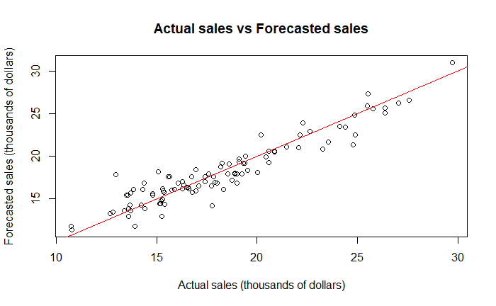

```r
#Plotting scatterplots of predicted versus actual values
plot(testSeat$Sales, predictions, xlab = "Actual sales (thousands of dollars)", ylab = "Forecasted sales (thousands of dollars)", main = "Actual sales vs Forecasted sales")
abline(a = 0, b = 1, col = "red")
```

```r
length(testSeat$Sales)
```

```
[1] 100
```

```r
length(predictions)
```

```
[1] 100
```